# Mushroom Data

Khang Pham, Don Pham

For this project we decided to use the mushroom data from the UCI Machine Learning Repository. This data includes descrptions of samples to 23 species of gilled mushrooms in ithe Agaricus and Lepitoa family. Each species is identifieed as a definitely edible, definitely poisonous, or of unkown edibility. There are 22 attributes for each mushroom. And the data are just letters corresponding to a chart that they provide. But in our data we renamed them our selves to make it easier to read.

In the following graphs, we show the number of mushrooms with a given cap color separated into two groups: poisonous mushrooms and edible mushrooms.

To produce our graphs we went through these steps.

1. Converted the .text data into .csv format and ran it into the reformatting data script.
2. Added an ID columns and populated it with numbers to both Mushroom data so we can join them later based on the ID.
3. Loaded up the data by importing the .csv file through SQL Developer.
4. On tableau we did a right join on Mushroom_ID.
5. Because the data that we have only had single letters represetting diffrent types we had to create a table calclulation. Pictured below.

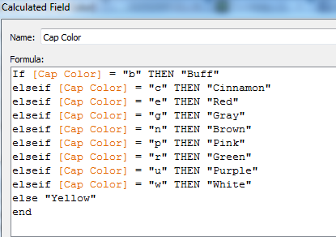

# Rank

The last column shows the rank of the cap colors in each group. Here we found out that the most popular color is brown shared between both groups of edible and poisonous.

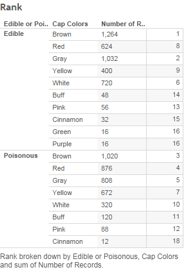

# Habitat

Here, we are showing the diffrent types of habitats that the mushrrooms grow in. From this data we found out that most of the mushrooms you find on paths you walk on is poisonous.

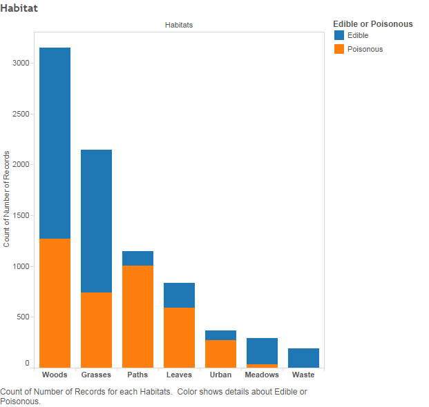

# Odors

This graph shows the odor the diffrent types of odor the mushrooms produce. Here we found out that the nice smelling mushrooms are edible while the bad smelling ones is poisonous.

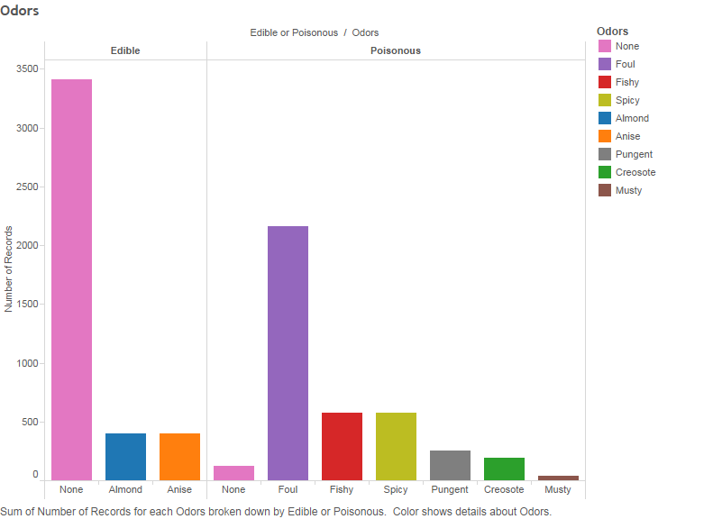

# Habitats and Cap Color

Here we combined habitats and color. One intresting thing we found from this graph is that 100% of Red mushrooms found in leaves are poisonous.

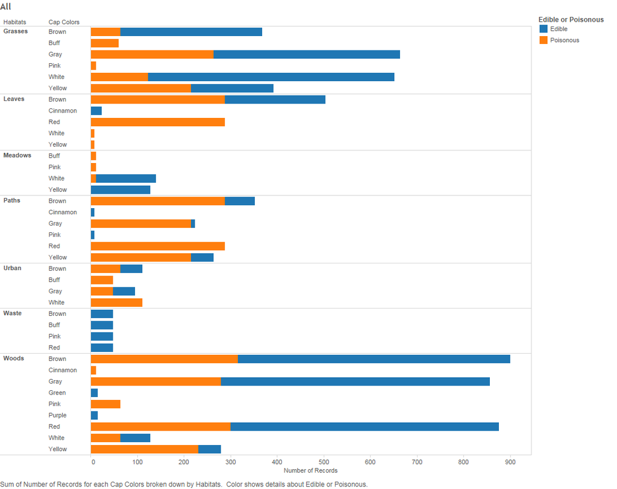